# ENGR-E 533 Deep Learning Systems - Assignment 1

## Name : Akhila Sakiramolla (asakiram@iu.edu)

## UID : 2000886005

## Importing required libraries

```python
import numpy as np
import pandas as pd
import matplotlib.pyplot as plt
import seaborn as sns
import tensorflow as tf
from sklearn.decomposition import PCA
from sklearn.manifold import TSNE
import keras
from tensorflow.keras import initializers
from keras.callbacks import History
from keras.models import Sequential
from keras.models import Model
from keras.layers import Dense
from keras.layers.core import Dense, Activation

# To execute a cell line by line
from IPython.core.interactiveshell import InteractiveShell
InteractiveShell.ast_node_interactivity = "all"
```

## Problem 1: A Detailed View to MNIST Classification

### 1.1 Training a fully-connected net for MNIST classification

```python
mnist = tf.keras.datasets.mnist
(x_train, y_train), (x_test, y_test) = mnist.load_data()
x_train.shape
y_train.shape
x_test.shape
y_test.shape
```

```
(60000, 28, 28)
```

```
(60000,)
```

```
(10000, 28, 28)
```

```
(10000,)
```

```python
# reshaping the data

x_train = x_train.reshape(60000, 784)
x_test = x_test.reshape(10000, 784)
```

```python
# Normalizing the data

x_train, x_test = x_train / 255.0, x_test / 255.0
```

```python
# Building a model and adding 5 hidden layers with 1024 hidden units and output layer with 10 units

model = Sequential()
model.add(Dense(1024, input_dim = 784))
model.add(Activation('relu'))
model.add(Dense(1024))
model.add(Activation('relu'))
model.add(Dense(1024))
model.add(Activation('relu'))
model.add(Dense(1024))
model.add(Activation('relu'))
model.add(Dense(1024))
model.add(Activation('relu'))
model.add(Dense(10))
model.add(Activation('softmax'))

model.summary()
```

```
Model: "sequential"
_________________________________________________________________
 Layer (type)                Output Shape              Param #
=================================================================
 dense (Dense)               (None, 1024)              803840

 activation (Activation)     (None, 1024)              0

 dense_1 (Dense)             (None, 1024)              1049600

 activation_1 (Activation)   (None, 1024)              0

 dense_2 (Dense)             (None, 1024)              1049600

 activation_2 (Activation)   (None, 1024)              0

 dense_3 (Dense)             (None, 1024)              1049600

 activation_3 (Activation)   (None, 1024)              0

 dense_4 (Dense)             (None, 1024)              1049600

 activation_4 (Activation)   (None, 1024)              0

 dense_5 (Dense)             (None, 10)                10250

 activation_5 (Activation)   (None, 10)                0

=================================================================
Total params: 5,012,490
Trainable params: 5,012,490
Non-trainable params: 0
_________________________________________________________________
```

```python
# Calculating loss and optimizing it

loss_fn = tf.keras.losses.SparseCategoricalCrossentropy(from_logits=True)
model.compile(optimizer='adam',
              loss=loss_fn,
              metrics=['accuracy'])
```

```python
# Fitting the model

model.fit(x_train, y_train, epochs=60, batch_size=50)
```

```
<keras.callbacks.History at 0x7fafd021a790>
```

```python
# Calculating test accuarcy

loss, accuracy = model.evaluate(x_test,  y_test, verbose=2)
print("Test accuracy:", round(accuracy*100,2))
```

```
313/313 - 1s - loss: 0.2163 - accuracy: 0.9831 - 627ms/epoch - 2ms/step
Test accuracy: 98.31
```

### 1.3 Feedforward step on your test samples

```python
x_test.shape
```

```
(10000, 784)
```

```python
x_test1000 = x_test[:1000]
y_test1000 = y_test[:1000]

softmax_preds = model.predict(x_test1000)
softmax_preds.shape
```

```
(1000, 10)
```

```python
# Creating a list to store maximum probability and its index

prob_mat = []
for j in range(softmax_preds.shape[0]):
  prob_mat.append([j,max(softmax_preds[j]),np.argmax(softmax_preds[j])])
prob_mat = np.array(prob_mat)
```

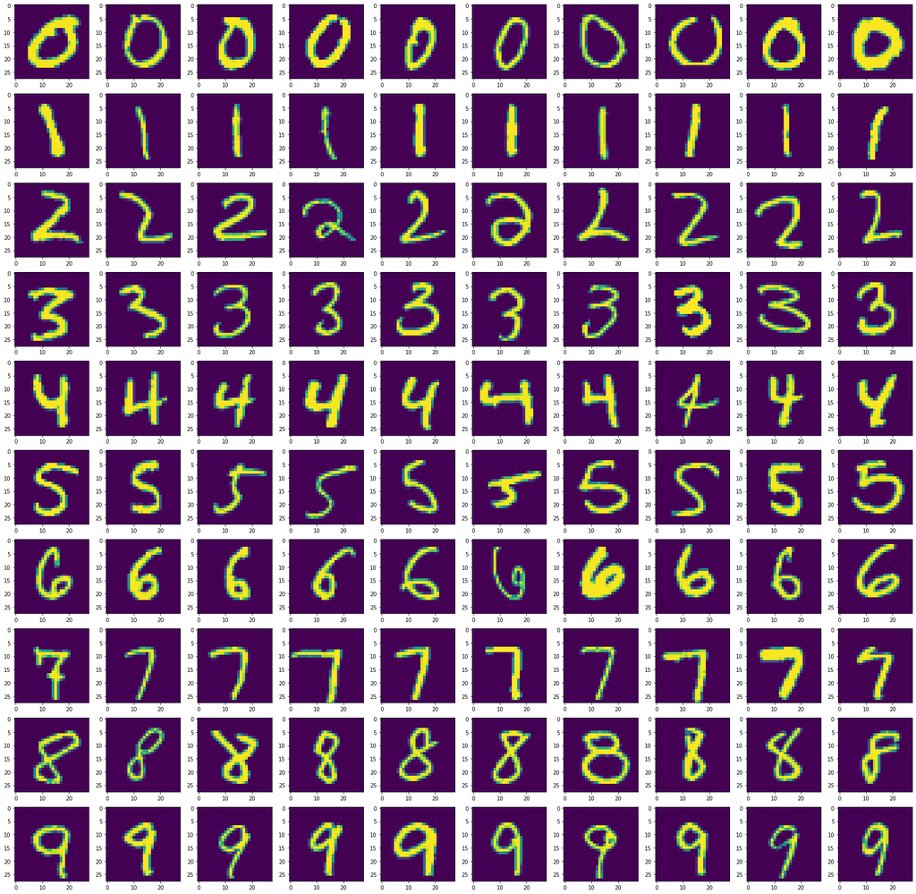

```python
# plotting the top probablities value of each label

fig, ax = plt.subplots(10,10,figsize=(30,30))
for i in range(10):
  prob_mat1 = prob_mat[prob_mat[:,2] == i]
  prob_mat1 = prob_mat1[prob_mat1[:,1].argsort()][::-1]
  prob_mat1 = prob_mat1[0:10]
  for j in range(prob_mat1.shape[0]):
    ax[i][j].imshow(x_test1000[int(prob_mat1[j][0])].reshape(28,28))
```

### 1.4 Repeat the procedure in Problem 1.3 for your second to the last layer output.

```python
# Extracting second to last layer output

model1 = Model(inputs=model.input,
                outputs=model.get_layer("dense_4").output)

softmax_preds1 = model1.predict(x_test1000)
```

```python
# Extracting 10 random columns

from random import randrange
b = [randrange(1024) for i in range(10)]
softmax_preds2 = softmax_preds1[:,b]
```

```python
# Creating a list to store maximum probability and its index

prob_mat = []
for j in range(softmax_preds2.shape[0]):
  prob_mat.append([j,max(softmax_preds2[j]),np.argmax(softmax_preds2[j])])
prob_mat = np.array(prob_mat)
```

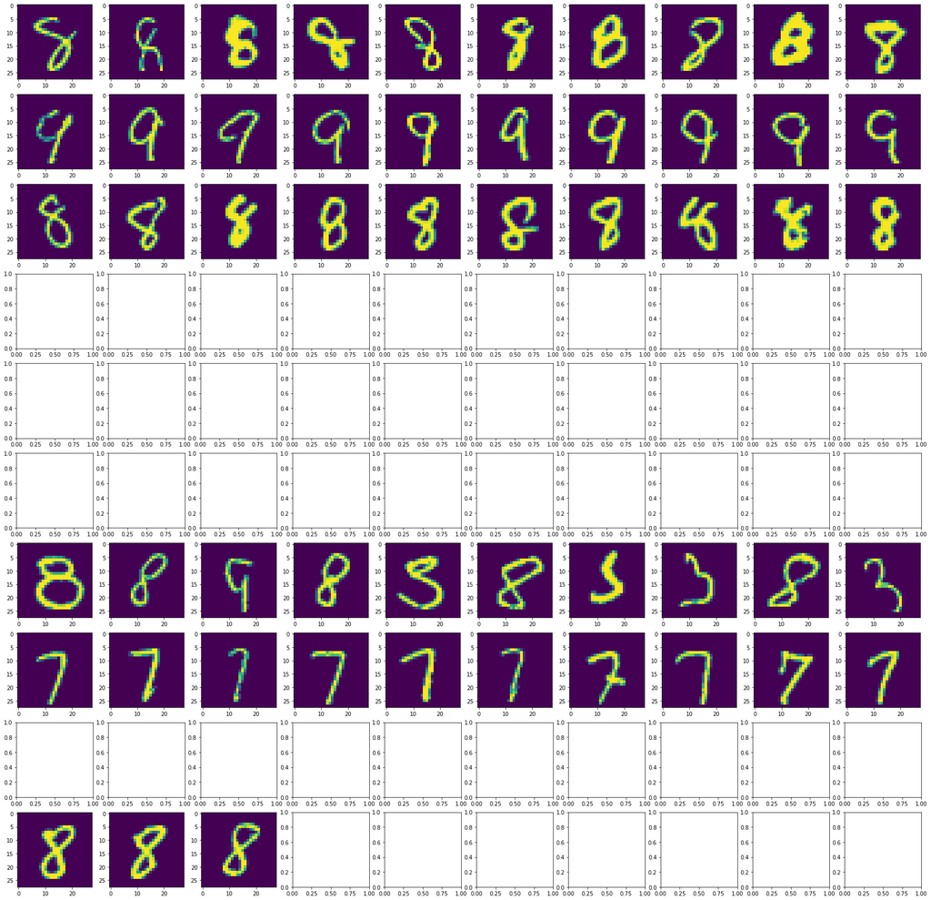

```python
# plotting the top probablities value of each label

fig, ax = plt.subplots(10,10,figsize=(30,30))
for i in range(10):
  prob_mat1 = prob_mat[prob_mat[:,2] == i]
  prob_mat1 = prob_mat1[prob_mat1[:,1].argsort()][::-1]
  prob_mat1 = prob_mat1[0:10]
  for j in range(prob_mat1.shape[0]):
    ax[i][j].imshow(x_test1000[int(prob_mat1[j][0])].reshape(28,28))
```

By randomly selecting 10 dimensions out of 1024 dimensions, we can see that they are able to capture the features of some of the digits. Some images are blank because these dimensions are not capturing any information about other digits. The ideal situation would be when data can be seperated based on its label.

### 1.5 tSNE and PCA

```python
x_test1000.shape
```

```
(1000, 784)
```

```python
y_test1000.shape
```

```
(1000,)
```

```python
cols = ['pixel'+str(i) for i in range(x_test1000.shape[1])]
df_test = pd.DataFrame(x_test1000,columns=cols)
df_test['y'] = y_test1000
df_test['label'] = df_test['y'].apply(lambda i: str(i))
```

```
Explained variation per principal component: [0.1003825  0.07777415]
```

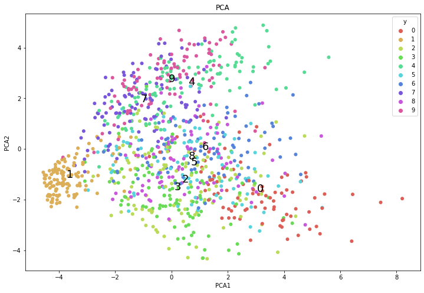

```python
# PCA

pca = PCA(n_components=2)
pca_result = pca.fit_transform(df_test[cols].values)
df_test['pca1'] = pca_result[:,0]
df_test['pca2'] = pca_result[:,1]

print('Explained variation per principal component: {}'.format(pca.explained_variance_ratio_))

pca_mean = df_test.groupby('label').agg({'pca1':'mean', 'pca2':'mean'})
pca_mean.reset_index(inplace = True)
pca1_mean = pca_mean['pca1'].values
pca2_mean = pca_mean['pca2'].values

plt.figure(figsize=(12,8))
sns.scatterplot(x="pca1", y="pca2", hue = 'y', palette=sns.color_palette("hls", 10), data=df_test, legend="full", edgecolor='None')
for i in range(0,10):
  plt.annotate(i, (pca1_mean[i], pca2_mean[i]),size=18)
plt.xlabel("PCA1")
plt.ylabel("PCA2")
plt.title("PCA")
```

```
[t-SNE] Computing 121 nearest neighbors...
[t-SNE] Indexed 1000 samples in 0.001s...
[t-SNE] Computed neighbors for 1000 samples in 0.053s...
[t-SNE] Computed conditional probabilities for sample 1000 / 1000
[t-SNE] Mean sigma: 2.674544
[t-SNE] KL divergence after 250 iterations with early exaggeration: 66.305130
[t-SNE] KL divergence after 300 iterations: 1.247954
```

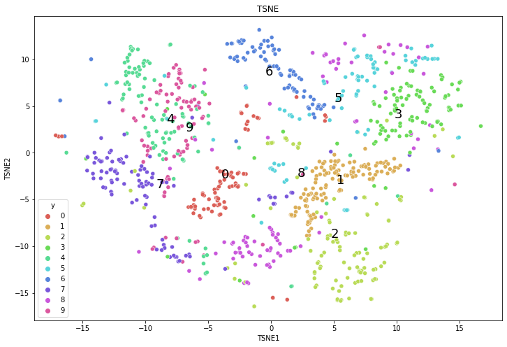

```python
# TSNE

tsne = TSNE(n_components=2, verbose=1, perplexity=40, n_iter=300)
tsne_results = tsne.fit_transform(x_test1000)

df_test['tsne1'] = tsne_results[:,0]
df_test['tsne2'] = tsne_results[:,1]

tsne_mean = df_test.groupby('label').agg({'tsne1':'mean', 'tsne2':'mean'})
tsne_mean.reset_index(inplace = True)
tsne1_mean = tsne_mean['tsne1'].values
tsne2_mean = tsne_mean['tsne2'].values

plt.figure(figsize=(12,8))
sns.scatterplot(x="tsne1", y="tsne2", hue="y", palette=sns.color_palette("hls", 10), data=df_test, legend="full")
for i in range(0,10):
  plt.annotate(i, (tsne1_mean[i], tsne2_mean[i]),size=18)
plt.xlabel("TSNE1")
plt.ylabel("TSNE2")
plt.title("TSNE")
```

We can observe that TSNE does a better job at classifying the labels than PCA.

### 1.7 Feedforward for different layers

#### First hidden layer output

```python
model_layer1 = Model(inputs=model.input,
                                 outputs=model.get_layer("activation").output)

preds_layer1 = model_layer1.predict(x_test1000)
preds_layer1.shape
```

```
(1000, 1024)
```

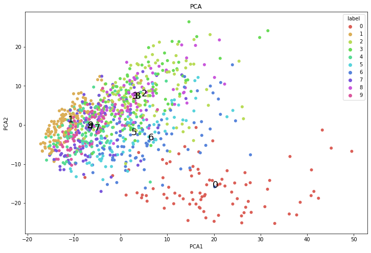

```python
# PCA

pca = PCA(n_components=2)
pca_result = pca.fit_transform(preds_layer1)
df_pca = pd.DataFrame(pca_result, columns =['pca1', 'pca2'])
df_pca['label'] = y_test1000

pca_mean = df_pca.groupby('label').agg({'pca1':'mean', 'pca2':'mean'})
pca_mean.reset_index(inplace = True)
pca1_mean = pca_mean['pca1'].values
pca2_mean = pca_mean['pca2'].values

plt.figure(figsize=(12,8))
sns.scatterplot(x="pca1", y="pca2", hue = 'label', palette=sns.color_palette("hls", 10), data=df_pca, legend="full", edgecolor='None')
for i in range(0,10):
  plt.annotate(i, (pca1_mean[i], pca2_mean[i]),size=18)
plt.xlabel("PCA1")
plt.ylabel("PCA2")
plt.title("PCA")
```

```
[t-SNE] Computing 121 nearest neighbors...
[t-SNE] Indexed 1000 samples in 0.002s...
[t-SNE] Computed neighbors for 1000 samples in 0.069s...
[t-SNE] Computed conditional probabilities for sample 1000 / 1000
[t-SNE] Mean sigma: 11.261536
[t-SNE] KL divergence after 250 iterations with early exaggeration: 66.764595
[t-SNE] KL divergence after 300 iterations: 0.920106
```

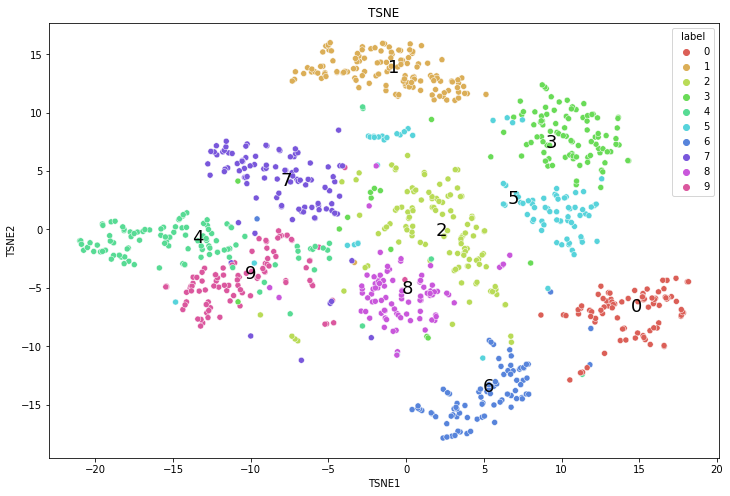

```python
# TSNE

tsne = TSNE(n_components=2, verbose=1, perplexity=40, n_iter=300)
tsne_results = tsne.fit_transform(preds_layer1)
df_tsne = pd.DataFrame(tsne_results, columns =['tsne1', 'tsne2'])
df_tsne['label'] = y_test1000

tsne_mean = df_tsne.groupby('label').agg({'tsne1':'mean', 'tsne2':'mean'})
tsne_mean.reset_index(inplace = True)
tsne1_mean = tsne_mean['tsne1'].values
tsne2_mean = tsne_mean['tsne2'].values

plt.figure(figsize=(12,8))
sns.scatterplot(x="tsne1", y="tsne2", hue="label", palette=sns.color_palette("hls", 10), data=df_tsne, legend="full")
for i in range(0,10):
  plt.annotate(i, (tsne1_mean[i], tsne2_mean[i]),size=18)
plt.xlabel("TSNE1")
plt.ylabel("TSNE2")
plt.title("TSNE")
```

The first hidden layer output gives better output with TSNE compared to PCA.

#### Second hidden layer output

```python
model_layer2 = Model(inputs=model.input,
                                 outputs=model.get_layer("activation_1").output)

preds_layer2 = model_layer2.predict(x_test1000)
```

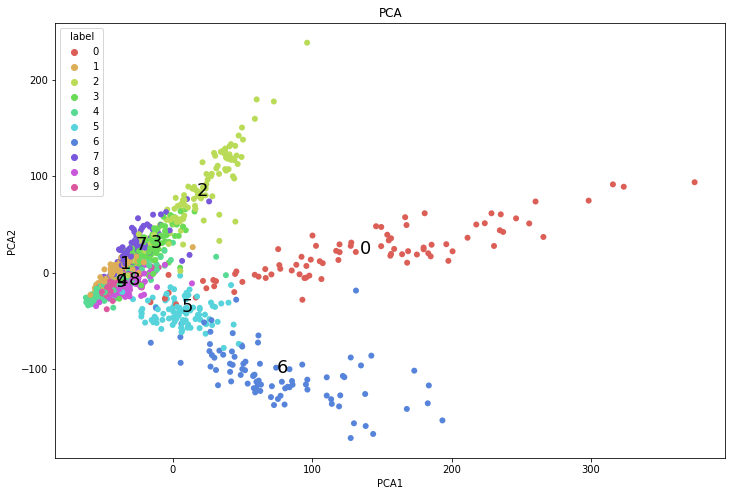

```python
# PCA

pca = PCA(n_components=2)
pca_result = pca.fit_transform(preds_layer2)
df_pca = pd.DataFrame(pca_result, columns =['pca1', 'pca2'])
df_pca['label'] = y_test1000

pca_mean = df_pca.groupby('label').agg({'pca1':'mean', 'pca2':'mean'})
pca_mean.reset_index(inplace = True)
pca1_mean = pca_mean['pca1'].values
pca2_mean = pca_mean['pca2'].values

plt.figure(figsize=(12,8))
sns.scatterplot(x="pca1", y="pca2", hue = 'label', palette=sns.color_palette("hls", 10), data=df_pca, legend="full", edgecolor='None')
for i in range(0,10):
  plt.annotate(i, (pca1_mean[i], pca2_mean[i]),size=18)
plt.xlabel("PCA1")
plt.ylabel("PCA2")
plt.title("PCA")
```

```
[t-SNE] Computing 121 nearest neighbors...
[t-SNE] Indexed 1000 samples in 0.001s...
[t-SNE] Computed neighbors for 1000 samples in 0.064s...
[t-SNE] Computed conditional probabilities for sample 1000 / 1000
[t-SNE] Mean sigma: 40.475457
[t-SNE] KL divergence after 250 iterations with early exaggeration: 54.154572
[t-SNE] KL divergence after 300 iterations: 0.527558
```

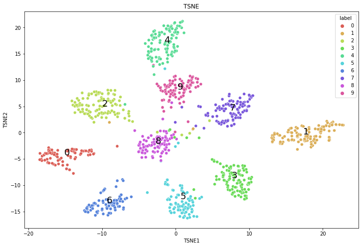

```python
# TSNE

tsne = TSNE(n_components=2, verbose=1, perplexity=40, n_iter=300)
tsne_results = tsne.fit_transform(preds_layer2)
df_tsne = pd.DataFrame(tsne_results, columns =['tsne1', 'tsne2'])
df_tsne['label'] = y_test1000

tsne_mean = df_tsne.groupby('label').agg({'tsne1':'mean', 'tsne2':'mean'})
tsne_mean.reset_index(inplace = True)
tsne1_mean = tsne_mean['tsne1'].values
tsne2_mean = tsne_mean['tsne2'].values

plt.figure(figsize=(12,8))
sns.scatterplot(x="tsne1", y="tsne2", hue="label", palette=sns.color_palette("hls", 10), data=df_tsne, legend="full")
for i in range(0,10):
  plt.annotate(i, (tsne1_mean[i], tsne2_mean[i]),size=18)
plt.xlabel("TSNE1")
plt.ylabel("TSNE2")
plt.title("TSNE")
```

TSNE on second layer output seems to almost classify all the labels correctly and is a good representation.

#### Third hidden layer output

```python
model_layer3 = Model(inputs=model.input,
                                 outputs=model.get_layer("activation_2").output)

preds_layer3 = model_layer3.predict(x_test1000)
```

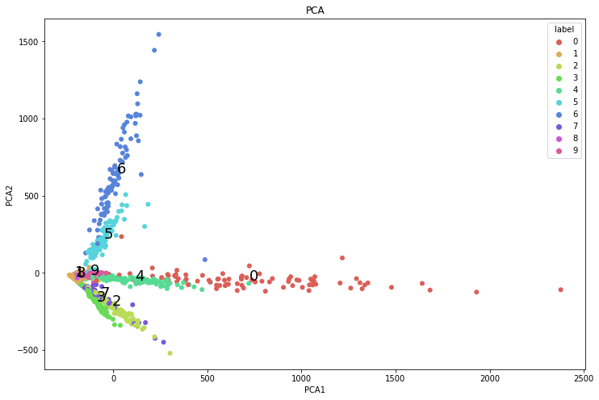

```python
# PCA

pca = PCA(n_components=2)
pca_result = pca.fit_transform(preds_layer3)
df_pca = pd.DataFrame(pca_result, columns =['pca1', 'pca2'])
df_pca['label'] = y_test1000

pca_mean = df_pca.groupby('label').agg({'pca1':'mean', 'pca2':'mean'})
pca_mean.reset_index(inplace = True)
pca1_mean = pca_mean['pca1'].values
pca2_mean = pca_mean['pca2'].values

plt.figure(figsize=(12,8))
sns.scatterplot(x="pca1", y="pca2", hue = 'label', palette=sns.color_palette("hls", 10), data=df_pca, legend="full", edgecolor='None')
for i in range(0,10):
  plt.annotate(i, (pca1_mean[i], pca2_mean[i]),size=18)
plt.xlabel("PCA1")
plt.ylabel("PCA2")
plt.title("PCA")
```

```
[t-SNE] Computing 121 nearest neighbors...
[t-SNE] Indexed 1000 samples in 0.001s...
[t-SNE] Computed neighbors for 1000 samples in 0.063s...
[t-SNE] Computed conditional probabilities for sample 1000 / 1000
[t-SNE] Mean sigma: 75.623211
[t-SNE] KL divergence after 250 iterations with early exaggeration: 46.125561
[t-SNE] KL divergence after 300 iterations: 0.310634
```

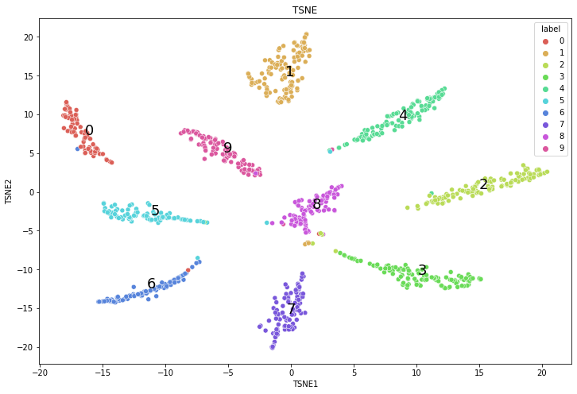

```python
# TSNE

tsne = TSNE(n_components=2, verbose=1, perplexity=40, n_iter=300)
tsne_results = tsne.fit_transform(preds_layer3)
df_tsne = pd.DataFrame(tsne_results, columns =['tsne1', 'tsne2'])
df_tsne['label'] = y_test1000

tsne_mean = df_tsne.groupby('label').agg({'tsne1':'mean', 'tsne2':'mean'})
tsne_mean.reset_index(inplace = True)
tsne1_mean = tsne_mean['tsne1'].values
tsne2_mean = tsne_mean['tsne2'].values

plt.figure(figsize=(12,8))
sns.scatterplot(x="tsne1", y="tsne2", hue="label", palette=sns.color_palette("hls", 10), data=df_tsne, legend="full")
for i in range(0,10):
  plt.annotate(i, (tsne1_mean[i], tsne2_mean[i]),size=18)
plt.xlabel("TSNE1")
plt.ylabel("TSNE2")
plt.title("TSNE")
```

TSNE on the third layer output seperated the data completely and the results hereafter will be completely seperated. So in order to get good classification, we can consider output of second or third layer.

#### Fourth hidden layer output

```python
model_layer4 = Model(inputs=model.input,
                                 outputs=model.get_layer("activation_3").output)

preds_layer4 = model_layer4.predict(x_test1000)
```

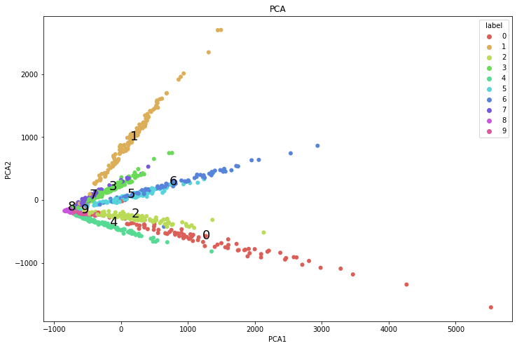

```python
# PCA

pca = PCA(n_components=2)
pca_result = pca.fit_transform(preds_layer4)
df_pca = pd.DataFrame(pca_result, columns =['pca1', 'pca2'])
df_pca['label'] = y_test1000

pca_mean = df_pca.groupby('label').agg({'pca1':'mean', 'pca2':'mean'})
pca_mean.reset_index(inplace = True)
pca1_mean = pca_mean['pca1'].values
pca2_mean = pca_mean['pca2'].values

plt.figure(figsize=(12,8))
sns.scatterplot(x="pca1", y="pca2", hue = 'label', palette=sns.color_palette("hls", 10), data=df_pca, legend="full", edgecolor='None')
for i in range(0,10):
  plt.annotate(i, (pca1_mean[i], pca2_mean[i]),size=18)
plt.xlabel("PCA1")
plt.ylabel("PCA2")
plt.title("PCA")
```

```
[t-SNE] Computing 121 nearest neighbors...
[t-SNE] Indexed 1000 samples in 0.001s...
[t-SNE] Computed neighbors for 1000 samples in 0.064s...
[t-SNE] Computed conditional probabilities for sample 1000 / 1000
[t-SNE] Mean sigma: 107.746388
[t-SNE] KL divergence after 250 iterations with early exaggeration: 47.028355
[t-SNE] KL divergence after 300 iterations: 0.272357
```

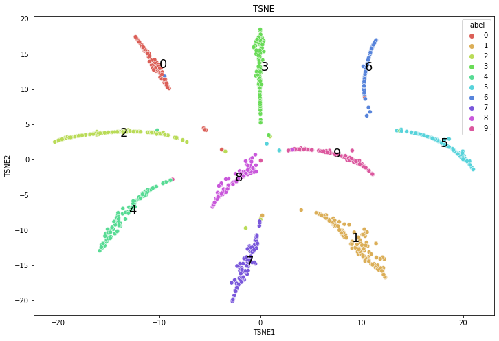

```python
# TSNE

tsne = TSNE(n_components=2, verbose=1, perplexity=40, n_iter=300)
tsne_results = tsne.fit_transform(preds_layer4)
df_tsne = pd.DataFrame(tsne_results, columns =['tsne1', 'tsne2'])
df_tsne['label'] = y_test1000

tsne_mean = df_tsne.groupby('label').agg({'tsne1':'mean', 'tsne2':'mean'})
tsne_mean.reset_index(inplace = True)
tsne1_mean = tsne_mean['tsne1'].values
tsne2_mean = tsne_mean['tsne2'].values

plt.figure(figsize=(12,8))
sns.scatterplot(x="tsne1", y="tsne2", hue="label", palette=sns.color_palette("hls", 10), data=df_tsne, legend="full")
for i in range(0,10):
  plt.annotate(i, (tsne1_mean[i], tsne2_mean[i]),size=18)
plt.xlabel("TSNE1")
plt.ylabel("TSNE2")
plt.title("TSNE")
```

#### Fifth hidden layer output

```python
model_layer5 = Model(inputs=model.input,
                                 outputs=model.get_layer("activation_4").output)

preds_layer5 = model_layer5.predict(x_test1000)
```

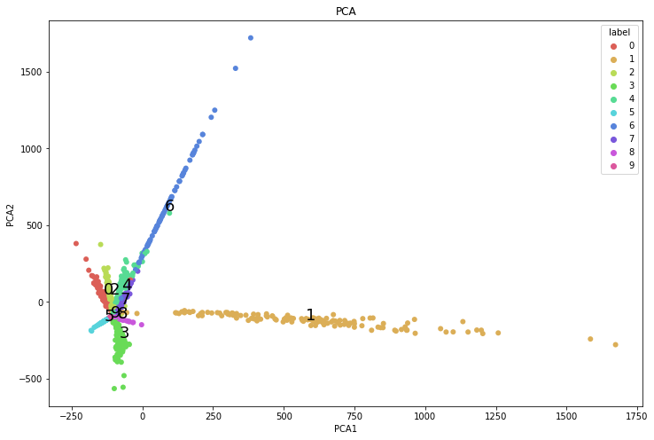

```python
# PCA

pca = PCA(n_components=2)
pca_result = pca.fit_transform(preds_layer5)
df_pca = pd.DataFrame(pca_result, columns =['pca1', 'pca2'])
df_pca['label'] = y_test1000

pca_mean = df_pca.groupby('label').agg({'pca1':'mean', 'pca2':'mean'})
pca_mean.reset_index(inplace = True)
pca1_mean = pca_mean['pca1'].values
pca2_mean = pca_mean['pca2'].values

plt.figure(figsize=(12,8))
sns.scatterplot(x="pca1", y="pca2", hue = 'label', palette=sns.color_palette("hls", 10), data=df_pca, legend="full", edgecolor='None')
for i in range(0,10):
  plt.annotate(i, (pca1_mean[i], pca2_mean[i]),size=18)
plt.xlabel("PCA1")
plt.ylabel("PCA2")
plt.title("PCA")
```

```
[t-SNE] Computing 121 nearest neighbors...
[t-SNE] Indexed 1000 samples in 0.001s...
[t-SNE] Computed neighbors for 1000 samples in 0.080s...
[t-SNE] Computed conditional probabilities for sample 1000 / 1000
[t-SNE] Mean sigma: 47.911606
[t-SNE] KL divergence after 250 iterations with early exaggeration: 46.303230
[t-SNE] KL divergence after 300 iterations: 0.237178
```

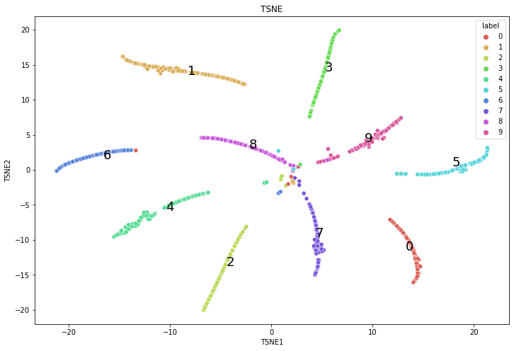

```python
# TSNE

tsne = TSNE(n_components=2, verbose=1, perplexity=40, n_iter=300)
tsne_results = tsne.fit_transform(preds_layer5)
df_tsne = pd.DataFrame(tsne_results, columns =['tsne1', 'tsne2'])
df_tsne['label'] = y_test1000

tsne_mean = df_tsne.groupby('label').agg({'tsne1':'mean', 'tsne2':'mean'})
tsne_mean.reset_index(inplace = True)
tsne1_mean = tsne_mean['tsne1'].values
tsne2_mean = tsne_mean['tsne2'].values

plt.figure(figsize=(12,8))
sns.scatterplot(x="tsne1", y="tsne2", hue="label", palette=sns.color_palette("hls", 10), data=df_tsne, legend="full")
for i in range(0,10):
  plt.annotate(i, (tsne1_mean[i], tsne2_mean[i]),size=18)
plt.xlabel("TSNE1")
plt.ylabel("TSNE2")
plt.title("TSNE")
```

## Problem 2: Adult Optimization

```python
mnist = tf.keras.datasets.mnist
(x_train, y_train), (x_test, y_test) = mnist.load_data()
```

```python
# Normalizing the data

x_train, x_test = x_train / 255.0, x_test / 255.0
```

### SGD optimizer

#### a) Activation function: the logistic sigmoid function; initialization: random numbers generated from the normal distribution (µ = 0, σ = 0.01)

```python
# Building a model and adding 5 hidden layers with 1024 hidden units and output layer with 10 units

hist = History()

model = tf.keras.models.Sequential([
  tf.keras.layers.Flatten(input_shape = (28,28)),
  tf.keras.layers.Dense(512, activation='sigmoid', kernel_initializer=tf.keras.initializers.RandomNormal(mean=0, stddev=0.01), name='hl1'),
  tf.keras.layers.Dense(512, activation='sigmoid', kernel_initializer=tf.keras.initializers.RandomNormal(mean=0, stddev=0.01), name='hl2'),
  tf.keras.layers.Dense(512, activation='sigmoid', kernel_initializer=tf.keras.initializers.RandomNormal(mean=0, stddev=0.01), name='hl3'),
  tf.keras.layers.Dense(512, activation='sigmoid', kernel_initializer=tf.keras.initializers.RandomNormal(mean=0, stddev=0.01), name='hl4'),
  tf.keras.layers.Dense(512, activation='sigmoid', kernel_initializer=tf.keras.initializers.RandomNormal(mean=0, stddev=0.01), name= 'hl5'),
  tf.keras.layers.Dense(10, activation='softmax', kernel_initializer=tf.keras.initializers.RandomNormal(mean=0, stddev=0.01))])

model.summary()
```

```
Model: "sequential_1"
_________________________________________________________________
 Layer (type)                Output Shape              Param #
=================================================================
 flatten (Flatten)           (None, 784)               0

 hl1 (Dense)                 (None, 512)               401920

 hl2 (Dense)                 (None, 512)               262656

 hl3 (Dense)                 (None, 512)               262656

 hl4 (Dense)                 (None, 512)               262656

 hl5 (Dense)                 (None, 512)               262656

 dense_6 (Dense)             (None, 10)                5130

=================================================================
Total params: 1,457,674
Trainable params: 1,457,674
Non-trainable params: 0
_________________________________________________________________
```

```python
# Calculating loss and optimizing it

loss_fn = tf.keras.losses.SparseCategoricalCrossentropy(from_logits=True)
model.compile(optimizer=tf.keras.optimizers.SGD(learning_rate=0.01),
              loss=loss_fn,
              metrics=['accuracy'])
```

```python
# Fitting the model

model.fit(x_train, y_train, validation_data=(x_test,y_test), epochs=350, callbacks=[hist], batch_size=150)
```

```
<keras.callbacks.History at 0x7faf1f0db150>
```

```python
sgd_acc1 = hist.history['val_accuracy']
```

#### b) Activation function: the logistic sigmoid function; initialization: Xavier initializer

```python
# Building a model and adding 5 hidden layers with 1024 hidden units and output layer with 10 units

hist = History()

model = tf.keras.models.Sequential([
  tf.keras.layers.Flatten(input_shape = (28,28)),
  tf.keras.layers.Dense(512, activation='sigmoid', kernel_initializer=tf.keras.initializers.GlorotNormal(), name='hl1'),
  tf.keras.layers.Dense(512, activation='sigmoid', kernel_initializer=tf.keras.initializers.GlorotNormal(), name='hl2'),
  tf.keras.layers.Dense(512, activation='sigmoid', kernel_initializer=tf.keras.initializers.GlorotNormal(), name='hl3'),
  tf.keras.layers.Dense(512, activation='sigmoid', kernel_initializer=tf.keras.initializers.GlorotNormal(), name='hl4'),
  tf.keras.layers.Dense(512, activation='sigmoid', kernel_initializer=tf.keras.initializers.GlorotNormal(), name= 'hl5'),
  tf.keras.layers.Dense(10, activation='softmax', kernel_initializer=tf.keras.initializers.GlorotNormal())])

model.summary()
```

```
Model: "sequential_2"
_________________________________________________________________
 Layer (type)                Output Shape              Param #
=================================================================
 flatten_1 (Flatten)         (None, 784)               0

 hl1 (Dense)                 (None, 512)               401920

 hl2 (Dense)                 (None, 512)               262656

 hl3 (Dense)                 (None, 512)               262656

 hl4 (Dense)                 (None, 512)               262656

 hl5 (Dense)                 (None, 512)               262656

 dense_7 (Dense)             (None, 10)                5130

=================================================================
Total params: 1,457,674
Trainable params: 1,457,674
Non-trainable params: 0
_________________________________________________________________
```

```python
# Calculating loss and optimizing it

loss_fn = tf.keras.losses.SparseCategoricalCrossentropy(from_logits=True)
model.compile(optimizer=tf.keras.optimizers.SGD(learning_rate=0.01),
              loss=loss_fn,
              metrics=['accuracy'])
```

```python
# Fitting the model

model.fit(x_train, y_train, validation_data=(x_test,y_test), epochs=350, callbacks=[hist], batch_size=150)
```

```
<keras.callbacks.History at 0x7faf1ef18f10>
```

```python
sgd_acc2 = hist.history['val_accuracy']
```

#### c) Activation function: ReLU; initialization: random numbers generated from the normal distribution (µ = 0, σ = 0.01)

```python
# Building a model and adding 5 hidden layers with 1024 hidden units and output layer with 10 units

hist = History()

model = tf.keras.models.Sequential([
  tf.keras.layers.Flatten(input_shape = (28,28)),
  tf.keras.layers.Dense(512, activation='relu', kernel_initializer=tf.random_normal_initializer(mean=0.0, stddev=0.01), name='hl1'),
  tf.keras.layers.Dense(512, activation='relu', kernel_initializer=tf.random_normal_initializer(mean=0.0, stddev=0.01), name='hl2'),
  tf.keras.layers.Dense(512, activation='relu', kernel_initializer=tf.random_normal_initializer(mean=0.0, stddev=0.01), name='hl3'),
  tf.keras.layers.Dense(512, activation='relu', kernel_initializer=tf.random_normal_initializer(mean=0.0, stddev=0.01), name='hl4'),
  tf.keras.layers.Dense(512, activation='relu', kernel_initializer=tf.random_normal_initializer(mean=0.0, stddev=0.01), name= 'hl5'),
  tf.keras.layers.Dense(10, activation='softmax', kernel_initializer=tf.random_normal_initializer(mean=0.0, stddev=0.01))])

model.summary()
```

```
Model: "sequential_3"
_________________________________________________________________
 Layer (type)                Output Shape              Param #
=================================================================
 flatten_2 (Flatten)         (None, 784)               0

 hl1 (Dense)                 (None, 512)               401920

 hl2 (Dense)                 (None, 512)               262656

 hl3 (Dense)                 (None, 512)               262656

 hl4 (Dense)                 (None, 512)               262656

 hl5 (Dense)                 (None, 512)               262656

 dense_8 (Dense)             (None, 10)                5130

=================================================================
Total params: 1,457,674
Trainable params: 1,457,674
Non-trainable params: 0
_________________________________________________________________
```

```python
# Calculating loss and optimizing it

loss_fn = tf.keras.losses.SparseCategoricalCrossentropy(from_logits=True)
model.compile(optimizer=tf.keras.optimizers.SGD(learning_rate=0.01),
              loss=loss_fn,
              metrics=['accuracy'])
```

```python
# Fitting the model

model.fit(x_train, y_train,validation_data=(x_test,y_test), epochs=350, callbacks=[hist], batch_size=150)
```

```
<keras.callbacks.History at 0x7faf1f07c510>
```

```python
sgd_acc3 = hist.history['val_accuracy']
```

#### d) Activation function: ReLU; initialization: Xavier initializer

```python
# Building a model and adding 5 hidden layers with 1024 hidden units and output layer with 10 units

hist = History()

model = tf.keras.models.Sequential([
  tf.keras.layers.Flatten(input_shape = (28,28)),
  tf.keras.layers.Dense(512, activation='relu', kernel_initializer=tf.keras.initializers.GlorotNormal(), name='hl1'),
  tf.keras.layers.Dense(512, activation='relu', kernel_initializer=tf.keras.initializers.GlorotNormal(), name='hl2'),
  tf.keras.layers.Dense(512, activation='relu', kernel_initializer=tf.keras.initializers.GlorotNormal(), name='hl3'),
  tf.keras.layers.Dense(512, activation='relu', kernel_initializer=tf.keras.initializers.GlorotNormal(), name='hl4'),
  tf.keras.layers.Dense(512, activation='relu', kernel_initializer=tf.keras.initializers.GlorotNormal(), name= 'hl5'),
  tf.keras.layers.Dense(10, activation='softmax', kernel_initializer=tf.keras.initializers.GlorotNormal())])

model.summary()
```

```
Model: "sequential_4"
_________________________________________________________________
 Layer (type)                Output Shape              Param #
=================================================================
 flatten_3 (Flatten)         (None, 784)               0

 hl1 (Dense)                 (None, 512)               401920

 hl2 (Dense)                 (None, 512)               262656

 hl3 (Dense)                 (None, 512)               262656

 hl4 (Dense)                 (None, 512)               262656

 hl5 (Dense)                 (None, 512)               262656

 dense_9 (Dense)             (None, 10)                5130

=================================================================
Total params: 1,457,674
Trainable params: 1,457,674
Non-trainable params: 0
_________________________________________________________________
```

```python
# Calculating loss and optimizing it

loss_fn = tf.keras.losses.SparseCategoricalCrossentropy(from_logits=True)
model.compile(optimizer=tf.keras.optimizers.SGD(learning_rate=0.01),
              loss=loss_fn,
              metrics=['accuracy'])
```

```python
# Fitting the model

model.fit(x_train, y_train, validation_data=(x_test,y_test), epochs=350, callbacks=[hist], batch_size=150)
```

```
<keras.callbacks.History at 0x7faf1eaa28d0>
```

```python
sgd_acc4 = hist.history['val_accuracy']
```

#### e) Activation function: ReLU; initialization: Kaiming He’s initializer

```python
# Building a model and adding 5 hidden layers with 1024 hidden units and output layer with 10 units

hist = History()

model = tf.keras.models.Sequential([
  tf.keras.layers.Flatten(input_shape = (28,28)),
  tf.keras.layers.Dense(512, activation='relu', kernel_initializer=tf.keras.initializers.HeNormal(), name='hl1'),
  tf.keras.layers.Dense(512, activation='relu', kernel_initializer=tf.keras.initializers.HeNormal(), name='hl2'),
  tf.keras.layers.Dense(512, activation='relu', kernel_initializer=tf.keras.initializers.HeNormal(), name='hl3'),
  tf.keras.layers.Dense(512, activation='relu', kernel_initializer=tf.keras.initializers.HeNormal(), name='hl4'),
  tf.keras.layers.Dense(512, activation='relu', kernel_initializer=tf.keras.initializers.HeNormal(), name= 'hl5'),
  tf.keras.layers.Dense(10, activation='softmax', kernel_initializer=tf.keras.initializers.HeNormal())])

model.summary()
```

```
Model: "sequential_5"
_________________________________________________________________
 Layer (type)                Output Shape              Param #
=================================================================
 flatten_4 (Flatten)         (None, 784)               0

 hl1 (Dense)                 (None, 512)               401920

 hl2 (Dense)                 (None, 512)               262656

 hl3 (Dense)                 (None, 512)               262656

 hl4 (Dense)                 (None, 512)               262656

 hl5 (Dense)                 (None, 512)               262656

 dense_10 (Dense)            (None, 10)                5130

=================================================================
Total params: 1,457,674
Trainable params: 1,457,674
Non-trainable params: 0
_________________________________________________________________
```

```python
# Calculating loss and optimizing it

loss_fn = tf.keras.losses.SparseCategoricalCrossentropy(from_logits=True)
model.compile(optimizer=tf.keras.optimizers.SGD(learning_rate=0.01),
              loss=loss_fn,
              metrics=['accuracy'])
```

```python
# Fitting the model

model.fit(x_train, y_train, validation_data=(x_test,y_test), epochs=350, callbacks=[hist], batch_size=150)
```

```
<keras.callbacks.History at 0x7faf1e940dd0>
```

```python
sgd_acc5 = hist.history['val_accuracy']
```

#### Plotting the learning curve

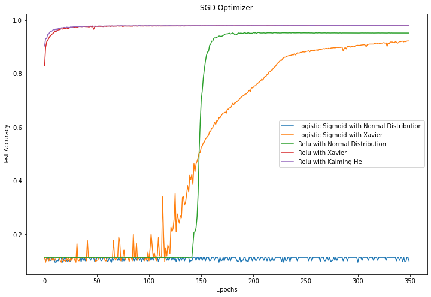

```python
df_sgd_acc = pd.DataFrame(list(zip(sgd_acc1, sgd_acc2, sgd_acc3, sgd_acc4, sgd_acc5)),
               columns =['sig_rand_acc', 'sig_xavier_acc', 'relu_rand_acc', 'relu_xavier_acc', 'relu_kaiming_acc'])
df_sgd_acc['epochs'] = [i for i in range(1,351)]

plt.figure(figsize=(12,8))
plt.plot(df_sgd_acc['sig_rand_acc'],label='Logistic Sigmoid with Normal Distribution')
plt.plot(df_sgd_acc['sig_xavier_acc'],label='Logistic Sigmoid with Xavier')
plt.plot(df_sgd_acc['relu_rand_acc'],label='Relu with Normal Distribution')
plt.plot(df_sgd_acc['relu_xavier_acc'],label='Relu with Xavier')
plt.plot(df_sgd_acc['relu_kaiming_acc'],label='Relu with Kaiming He')
plt.xlabel('Epochs')
plt.ylabel('Test Accuracy')
plt.title('SGD Optimizer')
plt.legend()
```

I could not train more than 350 epochs due to computational constraints.

### Adam optimizer

#### a) Activation function: the logistic sigmoid function; initialization: random numbers generated from the normal distribution (µ = 0, σ = 0.01)

```python
# Building a model and adding 5 hidden layers with 1024 hidden units and output layer with 10 units

hist = History()

model = tf.keras.models.Sequential([
  tf.keras.layers.Flatten(input_shape = (28,28)),
  tf.keras.layers.Dense(512, activation='sigmoid', kernel_initializer=tf.keras.initializers.RandomNormal(mean=0, stddev=0.01), name='hl1'),
  tf.keras.layers.Dense(512, activation='sigmoid', kernel_initializer=tf.keras.initializers.RandomNormal(mean=0, stddev=0.01), name='hl2'),
  tf.keras.layers.Dense(512, activation='sigmoid', kernel_initializer=tf.keras.initializers.RandomNormal(mean=0, stddev=0.01), name='hl3'),
  tf.keras.layers.Dense(512, activation='sigmoid', kernel_initializer=tf.keras.initializers.RandomNormal(mean=0, stddev=0.01), name='hl4'),
  tf.keras.layers.Dense(512, activation='sigmoid', kernel_initializer=tf.keras.initializers.RandomNormal(mean=0, stddev=0.01), name= 'hl5'),
  tf.keras.layers.Dense(10, activation='softmax', kernel_initializer=tf.keras.initializers.RandomNormal(mean=0, stddev=0.01))])

model.summary()
```

```
Model: "sequential_6"
_________________________________________________________________
 Layer (type)                Output Shape              Param #
=================================================================
 flatten_5 (Flatten)         (None, 784)               0

 hl1 (Dense)                 (None, 512)               401920

 hl2 (Dense)                 (None, 512)               262656

 hl3 (Dense)                 (None, 512)               262656

 hl4 (Dense)                 (None, 512)               262656

 hl5 (Dense)                 (None, 512)               262656

 dense_11 (Dense)            (None, 10)                5130

=================================================================
Total params: 1,457,674
Trainable params: 1,457,674
Non-trainable params: 0
_________________________________________________________________
```

```python
# Calculating loss and optimizing it

loss_fn = tf.keras.losses.SparseCategoricalCrossentropy(from_logits=True)
model.compile(optimizer='adam',
              loss=loss_fn,
              metrics=['accuracy'])
```

```python
# Fitting the model

model.fit(x_train, y_train, validation_data=(x_test,y_test), epochs=20, callbacks=[hist], batch_size=50)
```

```
<keras.callbacks.History at 0x7faf1eac6f50>
```

```python
adam_acc1 = hist.history['val_accuracy']
```

#### b) Activation function: the logistic sigmoid function; initialization: Xavier initializer

```python
# Building a model and adding 5 hidden layers with 1024 hidden units and output layer with 10 units

hist = History()

model = tf.keras.models.Sequential([
  tf.keras.layers.Flatten(input_shape = (28,28)),
  tf.keras.layers.Dense(512, activation='sigmoid', kernel_initializer=tf.keras.initializers.GlorotNormal(), name='hl1'),
  tf.keras.layers.Dense(512, activation='sigmoid', kernel_initializer=tf.keras.initializers.GlorotNormal(), name='hl2'),
  tf.keras.layers.Dense(512, activation='sigmoid', kernel_initializer=tf.keras.initializers.GlorotNormal(), name='hl3'),
  tf.keras.layers.Dense(512, activation='sigmoid', kernel_initializer=tf.keras.initializers.GlorotNormal(), name='hl4'),
  tf.keras.layers.Dense(512, activation='sigmoid', kernel_initializer=tf.keras.initializers.GlorotNormal(), name= 'hl5'),
  tf.keras.layers.Dense(10, activation='softmax', kernel_initializer=tf.keras.initializers.GlorotNormal())])

model.summary()
```

```
Model: "sequential_7"
_________________________________________________________________
 Layer (type)                Output Shape              Param #
=================================================================
 flatten_6 (Flatten)         (None, 784)               0

 hl1 (Dense)                 (None, 512)               401920

 hl2 (Dense)                 (None, 512)               262656

 hl3 (Dense)                 (None, 512)               262656

 hl4 (Dense)                 (None, 512)               262656

 hl5 (Dense)                 (None, 512)               262656

 dense_12 (Dense)            (None, 10)                5130

=================================================================
Total params: 1,457,674
Trainable params: 1,457,674
Non-trainable params: 0
_________________________________________________________________
```

```python
# Calculating loss and optimizing it

loss_fn = tf.keras.losses.SparseCategoricalCrossentropy(from_logits=True)
model.compile(optimizer='adam',
              loss=loss_fn,
              metrics=['accuracy'])
```

```python
# Fitting the model

model.fit(x_train, y_train, validation_data=(x_test,y_test), epochs=20, callbacks=[hist], batch_size=50)
```

```
<keras.callbacks.History at 0x7faf194e85d0>
```

```python
adam_acc2 = hist.history['val_accuracy']
```

#### c) Activation function: ReLU; initialization: random numbers generated from the normal distribution (µ = 0, σ = 0.01)

```python
# Building a model and adding 5 hidden layers with 1024 hidden units and output layer with 10 units

hist = History()

model = tf.keras.models.Sequential([
  tf.keras.layers.Flatten(input_shape = (28,28)),
  tf.keras.layers.Dense(512, activation='relu', kernel_initializer=tf.random_normal_initializer(mean=0.0, stddev=0.01), name='hl1'),
  tf.keras.layers.Dense(512, activation='relu', kernel_initializer=tf.random_normal_initializer(mean=0.0, stddev=0.01), name='hl2'),
  tf.keras.layers.Dense(512, activation='relu', kernel_initializer=tf.random_normal_initializer(mean=0.0, stddev=0.01), name='hl3'),
  tf.keras.layers.Dense(512, activation='relu', kernel_initializer=tf.random_normal_initializer(mean=0.0, stddev=0.01), name='hl4'),
  tf.keras.layers.Dense(512, activation='relu', kernel_initializer=tf.random_normal_initializer(mean=0.0, stddev=0.01), name= 'hl5'),
  tf.keras.layers.Dense(10, activation='softmax', kernel_initializer=tf.random_normal_initializer(mean=0.0, stddev=0.01))])

model.summary()
```

```
Model: "sequential_8"
_________________________________________________________________
 Layer (type)                Output Shape              Param #
=================================================================
 flatten_7 (Flatten)         (None, 784)               0

 hl1 (Dense)                 (None, 512)               401920

 hl2 (Dense)                 (None, 512)               262656

 hl3 (Dense)                 (None, 512)               262656

 hl4 (Dense)                 (None, 512)               262656

 hl5 (Dense)                 (None, 512)               262656

 dense_13 (Dense)            (None, 10)                5130

=================================================================
Total params: 1,457,674
Trainable params: 1,457,674
Non-trainable params: 0
_________________________________________________________________
```

```python
# Calculating loss and optimizing it

loss_fn = tf.keras.losses.SparseCategoricalCrossentropy(from_logits=True)
model.compile(optimizer='adam',
              loss=loss_fn,
              metrics=['accuracy'])
```

```python
# Fitting the model

model.fit(x_train, y_train,validation_data=(x_test,y_test), epochs=20, callbacks=[hist], batch_size=50)
```

```
<keras.callbacks.History at 0x7faf18b27e50>
```

```python
adam_acc3 = hist.history['val_accuracy']
```

#### d) Activation function: ReLU; initialization: Xavier initializer

```python
# Building a model and adding 5 hidden layers with 1024 hidden units and output layer with 10 units

hist = History()

model = tf.keras.models.Sequential([
  tf.keras.layers.Flatten(input_shape = (28,28)),
  tf.keras.layers.Dense(512, activation='relu', kernel_initializer=tf.keras.initializers.GlorotNormal(), name='hl1'),
  tf.keras.layers.Dense(512, activation='relu', kernel_initializer=tf.keras.initializers.GlorotNormal(), name='hl2'),
  tf.keras.layers.Dense(512, activation='relu', kernel_initializer=tf.keras.initializers.GlorotNormal(), name='hl3'),
  tf.keras.layers.Dense(512, activation='relu', kernel_initializer=tf.keras.initializers.GlorotNormal(), name='hl4'),
  tf.keras.layers.Dense(512, activation='relu', kernel_initializer=tf.keras.initializers.GlorotNormal(), name= 'hl5'),
  tf.keras.layers.Dense(10, activation='softmax', kernel_initializer=tf.keras.initializers.GlorotNormal())])

model.summary()
```

```
Model: "sequential_9"
_________________________________________________________________
 Layer (type)                Output Shape              Param #
=================================================================
 flatten_8 (Flatten)         (None, 784)               0

 hl1 (Dense)                 (None, 512)               401920

 hl2 (Dense)                 (None, 512)               262656

 hl3 (Dense)                 (None, 512)               262656

 hl4 (Dense)                 (None, 512)               262656

 hl5 (Dense)                 (None, 512)               262656

 dense_14 (Dense)            (None, 10)                5130

=================================================================
Total params: 1,457,674
Trainable params: 1,457,674
Non-trainable params: 0
_________________________________________________________________
```

```python
# Calculating loss and optimizing it

loss_fn = tf.keras.losses.SparseCategoricalCrossentropy(from_logits=True)
model.compile(optimizer='adam',
              loss=loss_fn,
              metrics=['accuracy'])
```

```python
# Fitting the model

model.fit(x_train, y_train, validation_data=(x_test,y_test), epochs=20, callbacks=[hist], batch_size=50)
```

```
<keras.callbacks.History at 0x7faf1898f250>
```

```python
adam_acc4 = hist.history['val_accuracy']
```

#### e) Activation function: ReLU; initialization: Kaiming He’s initializer

```python
# Building a model and adding 5 hidden layers with 1024 hidden units and output layer with 10 units

hist = History()

model = tf.keras.models.Sequential([
  tf.keras.layers.Flatten(input_shape = (28,28)),
  tf.keras.layers.Dense(512, activation='relu', kernel_initializer=tf.keras.initializers.HeNormal(), name='hl1'),
  tf.keras.layers.Dense(512, activation='relu', kernel_initializer=tf.keras.initializers.HeNormal(), name='hl2'),
  tf.keras.layers.Dense(512, activation='relu', kernel_initializer=tf.keras.initializers.HeNormal(), name='hl3'),
  tf.keras.layers.Dense(512, activation='relu', kernel_initializer=tf.keras.initializers.HeNormal(), name='hl4'),
  tf.keras.layers.Dense(512, activation='relu', kernel_initializer=tf.keras.initializers.HeNormal(), name= 'hl5'),
  tf.keras.layers.Dense(10, activation='softmax', kernel_initializer=tf.keras.initializers.HeNormal())])

model.summary()
```

```
Model: "sequential_10"
_________________________________________________________________
 Layer (type)                Output Shape              Param #
=================================================================
 flatten_9 (Flatten)         (None, 784)               0

 hl1 (Dense)                 (None, 512)               401920

 hl2 (Dense)                 (None, 512)               262656

 hl3 (Dense)                 (None, 512)               262656

 hl4 (Dense)                 (None, 512)               262656

 hl5 (Dense)                 (None, 512)               262656

 dense_15 (Dense)            (None, 10)                5130

=================================================================
Total params: 1,457,674
Trainable params: 1,457,674
Non-trainable params: 0
_________________________________________________________________
```

```python
# Calculating loss and optimizing it

loss_fn = tf.keras.losses.SparseCategoricalCrossentropy(from_logits=True)
model.compile(optimizer='adam',
              loss=loss_fn,
              metrics=['accuracy'])
```

```python
# Fitting the model

model.fit(x_train, y_train, validation_data=(x_test,y_test), epochs=20, callbacks=[hist], batch_size=50)
```

```
<keras.callbacks.History at 0x7faf18859f10>
```

```python
adam_acc5 = hist.history['val_accuracy']
```

#### Plotting the learning curve

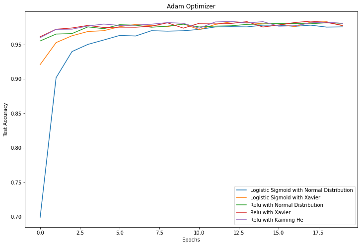

```python
df_adam_acc = pd.DataFrame(list(zip(adam_acc1, adam_acc2, adam_acc3, adam_acc4, adam_acc5)),
               columns =['sig_rand_acc', 'sig_xavier_acc', 'relu_rand_acc', 'relu_xavier_acc', 'relu_kaiming_acc'])
df_adam_acc['epochs'] = [i for i in range(1,21)]

plt.figure(figsize=(12,8))
plt.plot(df_adam_acc['sig_rand_acc'],label='Logistic Sigmoid with Normal Distribution')
plt.plot(df_adam_acc['sig_xavier_acc'],label='Logistic Sigmoid with Xavier')
plt.plot(df_adam_acc['relu_rand_acc'],label='Relu with Normal Distribution')
plt.plot(df_adam_acc['relu_xavier_acc'],label='Relu with Xavier')
plt.plot(df_adam_acc['relu_kaiming_acc'],label='Relu with Kaiming He')
plt.xlabel('Epochs')
plt.ylabel('Test Accuracy')
plt.title('Adam Optimizer')
plt.legend()
```

## Problem 3: Dropout

```python
mnist = tf.keras.datasets.mnist
(x_train, y_train), (x_test, y_test) = mnist.load_data()
x_train.shape
y_train.shape
x_test.shape
y_test.shape
```

```
(60000, 28, 28)
```

```
(60000,)
```

```
(10000, 28, 28)
```

```
(10000,)
```

```python
# Normalizing the data

x_train, x_test = x_train / 255.0, x_test / 255.0
```

#### a) Activation function: the logistic sigmoid function; initialization: Xavier initializer; no dropout

```python
# Building a model and adding 5 hidden layers with 1024 hidden units and output layer with 10 units

hist = History()

model = tf.keras.models.Sequential([
  tf.keras.layers.Flatten(input_shape = (28,28)),
  tf.keras.layers.Dense(1024, activation='sigmoid', kernel_initializer=tf.keras.initializers.GlorotNormal(), name='hl1'),
  tf.keras.layers.Dense(1024, activation='sigmoid', kernel_initializer=tf.keras.initializers.GlorotNormal(), name='hl2'),
  tf.keras.layers.Dense(1024, activation='sigmoid', kernel_initializer=tf.keras.initializers.GlorotNormal(), name='hl3'),
  tf.keras.layers.Dense(1024, activation='sigmoid', kernel_initializer=tf.keras.initializers.GlorotNormal(), name='hl4'),
  tf.keras.layers.Dense(1024, activation='sigmoid', kernel_initializer=tf.keras.initializers.GlorotNormal(), name= 'hl5'),
  tf.keras.layers.Dense(10, activation='softmax', kernel_initializer=tf.keras.initializers.GlorotNormal())])

model.summary()
```

```
Model: "sequential_11"
_________________________________________________________________
 Layer (type)                Output Shape              Param #
=================================================================
 flatten_10 (Flatten)        (None, 784)               0

 hl1 (Dense)                 (None, 1024)              803840

 hl2 (Dense)                 (None, 1024)              1049600

 hl3 (Dense)                 (None, 1024)              1049600

 hl4 (Dense)                 (None, 1024)              1049600

 hl5 (Dense)                 (None, 1024)              1049600

 dense_16 (Dense)            (None, 10)                10250

=================================================================
Total params: 5,012,490
Trainable params: 5,012,490
Non-trainable params: 0
_________________________________________________________________
```

```python
# Calculating loss and optimizing it

loss_fn = tf.keras.losses.SparseCategoricalCrossentropy(from_logits=True)
model.compile(optimizer='adam',
              loss=loss_fn,
              metrics=['accuracy'])
```

```python
# Fitting the model

model.fit(x_train, y_train, validation_data=(x_test,y_test), epochs=100, callbacks=[hist], batch_size=150)
```

```
<keras.callbacks.History at 0x7faf186a37d0>
```

```python
train_loss1 = hist.history['loss']
test_loss1 = hist.history['val_loss']
```

#### b) Activation function: the logistic sigmoid function; initialization: Xavier initializer; with dropout rate: 0.2 for the first layer and 0.5 for the other hidden layers

```python
# Building a model and adding 5 hidden layers with 1024 hidden units and output layer with 10 units

hist = History()

model = tf.keras.models.Sequential([
  tf.keras.layers.Flatten(input_shape = (28,28)),
  tf.keras.layers.Dense(1024, activation='sigmoid', kernel_initializer=tf.keras.initializers.GlorotNormal(), name='hl1'),
  tf.keras.layers.Dropout(0.2),
  tf.keras.layers.Dense(1024, activation='sigmoid', kernel_initializer=tf.keras.initializers.GlorotNormal(), name='hl2'),
  tf.keras.layers.Dropout(0.5),
  tf.keras.layers.Dense(1024, activation='sigmoid', kernel_initializer=tf.keras.initializers.GlorotNormal(), name='hl3'),
  tf.keras.layers.Dropout(0.5),
  tf.keras.layers.Dense(1024, activation='sigmoid', kernel_initializer=tf.keras.initializers.GlorotNormal(), name='hl4'),
  tf.keras.layers.Dropout(0.5),
  tf.keras.layers.Dense(1024, activation='sigmoid', kernel_initializer=tf.keras.initializers.GlorotNormal(), name= 'hl5'),
  tf.keras.layers.Dropout(0.5),
  tf.keras.layers.Dense(10, activation='softmax', kernel_initializer=tf.keras.initializers.GlorotNormal())])

model.summary()
```

```
Model: "sequential_12"
_________________________________________________________________
 Layer (type)                Output Shape              Param #
=================================================================
 flatten_11 (Flatten)        (None, 784)               0

 hl1 (Dense)                 (None, 1024)              803840

 dropout (Dropout)           (None, 1024)              0

 hl2 (Dense)                 (None, 1024)              1049600

 dropout_1 (Dropout)         (None, 1024)              0

 hl3 (Dense)                 (None, 1024)              1049600

 dropout_2 (Dropout)         (None, 1024)              0

 hl4 (Dense)                 (None, 1024)              1049600

 dropout_3 (Dropout)         (None, 1024)              0

 hl5 (Dense)                 (None, 1024)              1049600

 dropout_4 (Dropout)         (None, 1024)              0

 dense_17 (Dense)            (None, 10)                10250

=================================================================
Total params: 5,012,490
Trainable params: 5,012,490
Non-trainable params: 0
_________________________________________________________________
```

```python
# Calculating loss and optimizing it

loss_fn = tf.keras.losses.SparseCategoricalCrossentropy(from_logits=True)
model.compile(optimizer='adam',
              loss=loss_fn,
              metrics=['accuracy'])
```

```python
# Fitting the model

model.fit(x_train, y_train, validation_data=(x_test,y_test), epochs=100, callbacks=[hist], batch_size=150)
```

```
<keras.callbacks.History at 0x7faf16c558d0>
```

```python
train_loss2 = hist.history['loss']
test_loss2 = hist.history['val_loss']
```

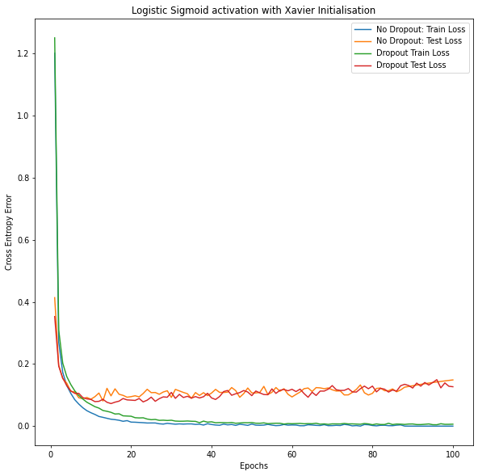

```python
df_sig_loss = pd.DataFrame(list(zip(train_loss1, test_loss1, train_loss2, test_loss2)),
               columns =['no_dropout_train_loss', 'no_dropout_test_loss', 'dropout_train_loss', 'dropout_test_loss'])
df_sig_loss['epochs'] = [i for i in range(1,101)]

plt.figure(figsize=(10, 10), dpi=70)
plt.plot(df_sig_loss['epochs'], df_sig_loss['no_dropout_train_loss'], label = "No Dropout: Train Loss")
plt.plot(df_sig_loss['epochs'], df_sig_loss['no_dropout_test_loss'], label = "No Dropout: Test Loss")
plt.plot(df_sig_loss['epochs'], df_sig_loss['dropout_train_loss'], label = "Dropout Train Loss")
plt.plot(df_sig_loss['epochs'], df_sig_loss['dropout_test_loss'] , label = "Dropout Test Loss")
plt.xlabel('Epochs')
plt.ylabel('Cross Entropy Error')
plt.title('Logistic Sigmoid activation with Xavier Initialisation')
plt.legend()
plt.show()
```

#### c) Activation function: ReLU; initialization: Kaiming He’s initializer; no dropout

```python
# Building a model and adding 5 hidden layers with 1024 hidden units and output layer with 10 units

hist = History()

model = tf.keras.models.Sequential([
  tf.keras.layers.Flatten(input_shape = (28,28)),
  tf.keras.layers.Dense(1024, activation='relu', kernel_initializer=tf.keras.initializers.HeNormal(), name='hl1'),
  tf.keras.layers.Dense(1024, activation='relu', kernel_initializer=tf.keras.initializers.HeNormal(), name='hl2'),
  tf.keras.layers.Dense(1024, activation='relu', kernel_initializer=tf.keras.initializers.HeNormal(), name='hl3'),
  tf.keras.layers.Dense(1024, activation='relu', kernel_initializer=tf.keras.initializers.HeNormal(), name='hl4'),
  tf.keras.layers.Dense(1024, activation='relu', kernel_initializer=tf.keras.initializers.HeNormal(), name= 'hl5'),
  tf.keras.layers.Dense(10, activation='softmax', kernel_initializer=tf.keras.initializers.HeNormal())])

model.summary()
```

```
Model: "sequential_13"
_________________________________________________________________
 Layer (type)                Output Shape              Param #
=================================================================
 flatten_12 (Flatten)        (None, 784)               0

 hl1 (Dense)                 (None, 1024)              803840

 hl2 (Dense)                 (None, 1024)              1049600

 hl3 (Dense)                 (None, 1024)              1049600

 hl4 (Dense)                 (None, 1024)              1049600

 hl5 (Dense)                 (None, 1024)              1049600

 dense_18 (Dense)            (None, 10)                10250

=================================================================
Total params: 5,012,490
Trainable params: 5,012,490
Non-trainable params: 0
_________________________________________________________________
```

```python
# Calculating loss and optimizing it

loss_fn = tf.keras.losses.SparseCategoricalCrossentropy(from_logits=True)
model.compile(optimizer='adam',
              loss=loss_fn,
              metrics=['accuracy'])
```

```python
# Fitting the model

model.fit(x_train, y_train, validation_data=(x_test,y_test), epochs=100, callbacks=[hist], batch_size=150)
```

```
<keras.callbacks.History at 0x7faf169c2ed0>
```

```python
train_loss1 = hist.history['loss']
test_loss1 = hist.history['val_loss']
```

#### d) Activation function: ReLU; initialization: Kaiming He’s initializer; with dropout rate: 0.2 for the first layer and 0.5 for the other hidden layers

```python
# Building a model and adding 5 hidden layers with 1024 hidden units and output layer with 10 units

hist = History()

model = tf.keras.models.Sequential([
  tf.keras.layers.Flatten(input_shape = (28,28)),
  tf.keras.layers.Dense(1024, activation='relu', kernel_initializer=tf.keras.initializers.HeNormal(), name='hl1'),
  tf.keras.layers.Dropout(0.2, noise_shape=None),
  tf.keras.layers.Dense(1024, activation='relu', kernel_initializer=tf.keras.initializers.HeNormal(), name='hl2'),
  tf.keras.layers.Dropout(0.5, noise_shape=None),
  tf.keras.layers.Dense(1024, activation='relu', kernel_initializer=tf.keras.initializers.HeNormal(), name='hl3'),
  tf.keras.layers.Dropout(0.5, noise_shape=None),
  tf.keras.layers.Dense(1024, activation='relu', kernel_initializer=tf.keras.initializers.HeNormal(), name='hl4'),
  tf.keras.layers.Dropout(0.5, noise_shape=None),
  tf.keras.layers.Dense(1024, activation='relu', kernel_initializer=tf.keras.initializers.HeNormal(), name= 'hl5'),
  tf.keras.layers.Dropout(0.5, noise_shape=None),
  tf.keras.layers.Dense(10, activation='softmax', kernel_initializer=tf.keras.initializers.HeNormal())])

model.summary()
```

```
Model: "sequential_14"
_________________________________________________________________
 Layer (type)                Output Shape              Param #
=================================================================
 flatten_13 (Flatten)        (None, 784)               0

 hl1 (Dense)                 (None, 1024)              803840

 dropout_5 (Dropout)         (None, 1024)              0

 hl2 (Dense)                 (None, 1024)              1049600

 dropout_6 (Dropout)         (None, 1024)              0

 hl3 (Dense)                 (None, 1024)              1049600

 dropout_7 (Dropout)         (None, 1024)              0

 hl4 (Dense)                 (None, 1024)              1049600

 dropout_8 (Dropout)         (None, 1024)              0

 hl5 (Dense)                 (None, 1024)              1049600

 dropout_9 (Dropout)         (None, 1024)              0

 dense_19 (Dense)            (None, 10)                10250

=================================================================
Total params: 5,012,490
Trainable params: 5,012,490
Non-trainable params: 0
_________________________________________________________________
```

```python
# Calculating loss and optimizing it

loss_fn = tf.keras.losses.SparseCategoricalCrossentropy(from_logits=True)
model.compile(optimizer='adam',
              loss=loss_fn,
              metrics=['accuracy'])
```

```python
# Fitting the model

model.fit(x_train, y_train, validation_data=(x_test,y_test), epochs=100, callbacks=[hist], batch_size=150)
```

```
<keras.callbacks.History at 0x7faf167c6610>
```

```python
train_loss2 = hist.history['loss']
test_loss2 = hist.history['val_loss']
```

```
(-0.5, 4.0)
```

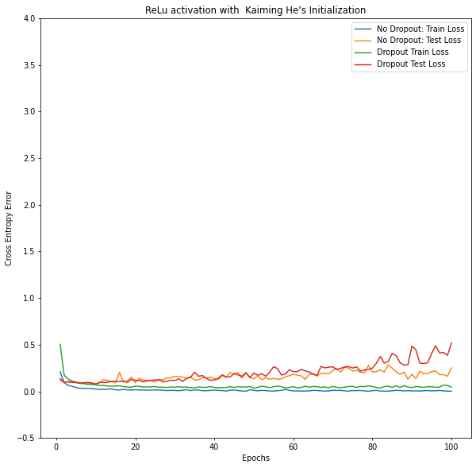

```python
df_relu_loss = pd.DataFrame(list(zip(train_loss1, test_loss1, train_loss2, test_loss2)),
               columns =['no_dropout_train_loss', 'no_dropout_test_loss', 'dropout_train_loss', 'dropout_test_loss'])
df_relu_loss['epochs'] = [i for i in range(1,101)]

plt.figure(figsize=(10, 10), dpi=70)
plt.plot(df_relu_loss['epochs'], df_relu_loss['no_dropout_train_loss'], label = "No Dropout: Train Loss")
plt.plot(df_relu_loss['epochs'], df_relu_loss['no_dropout_test_loss'], label = "No Dropout: Test Loss")
plt.plot(df_relu_loss['epochs'], df_relu_loss['dropout_train_loss'], label = "Dropout Train Loss")
plt.plot(df_relu_loss['epochs'], df_relu_loss['dropout_test_loss'] , label = "Dropout Test Loss")
plt.ylim(-0.5, 4)
plt.xlabel('Epochs')
plt.ylabel('Cross Entropy Error')
plt.title('ReLu activation with  Kaiming He’s Initialization')
plt.legend()
plt.show()
```

I saw similar trends even after training for more than 200 epochs.